# Predicting recall RT with 2AFC RT (v2.0B)

March 4, 2021

### March 4 update

- Adding 30 more participants
- Add simulated pairings analysis

### Exclusions

- Excluding 0 participants who gave incorrect resonses on fewer than 25% of recall trials, leaving 56 participants in the analysis.
- Dropping 53 recall trials with reaction times over more than 3 sds above the mean (more than 5.6 seconds), leaving 1011 trials in the analysis.

## Simulating pairings

For example, x axis are index for 10 pairs ordered by (easy-hard), there is a red line representing easy and blue line representing hard. each data point on red or blue is mean of 30 subjects, then add error bar - then we can see if the blue and red line get more apart as the (easy-hard) is increasing

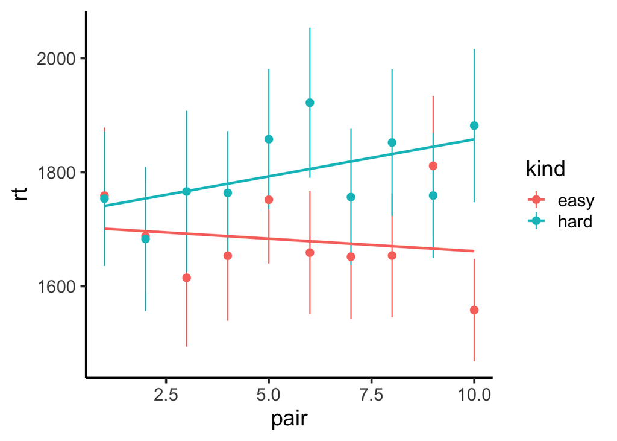

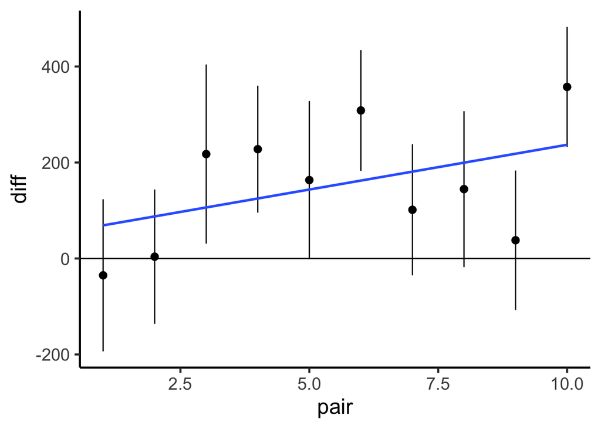

|  | Est. | S.E. | t val. | p |
| --- | --- | --- | --- | --- |
| (Intercept) | 152.666 | 47.013 | 3.247 | 0.001 |
| pair | 53.844 | 47.065 | 1.144 | 0.253 |

Standard errors: OLS; Continuous predictors are mean-centered and scaled by 1 s.d.

## AFC RT -> Recall RT

We want to see if the reaction time on 2AFC trials for a given word are predictive of reaction time for the same word in the recall task.

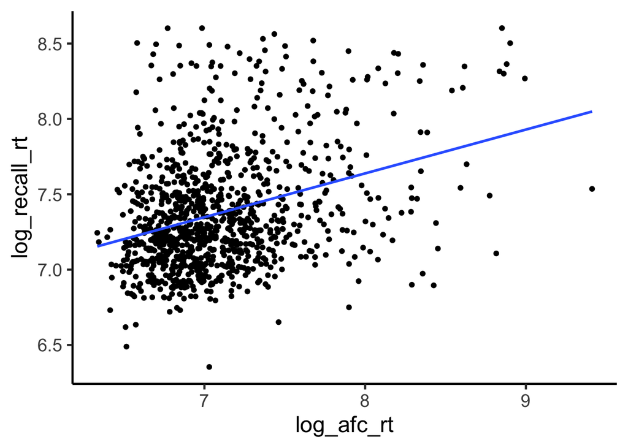

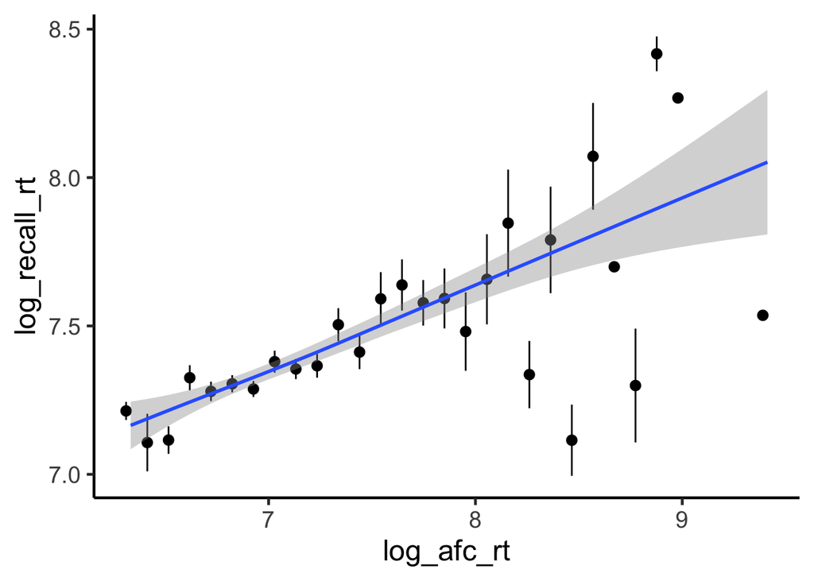

|  | Est. | S.E. | t val. | p |
| --- | --- | --- | --- | --- |
| (Intercept) | 5.313 | 0.186 | 28.591 | 0.000 |
| log_afc_rt | 0.291 | 0.026 | 11.124 | 0.000 |

Standard errors: OLS

This looks promising, but it could be driven by individual differences. We need to see the effect within individuals.

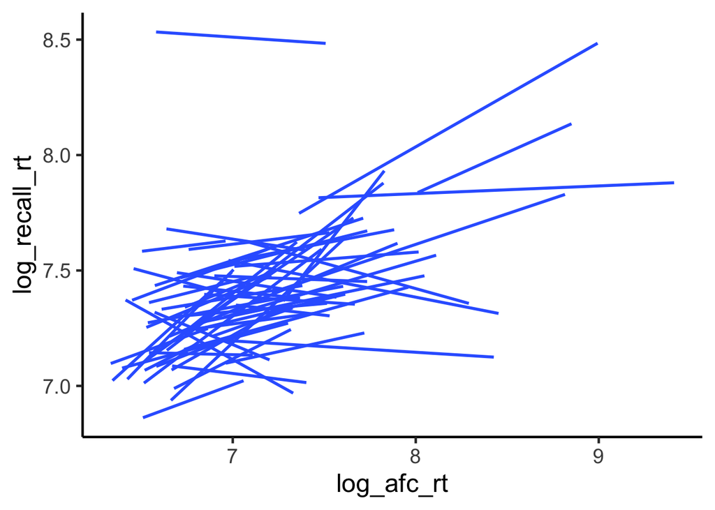

| Fixed Effects | Fixed Effects Est. | Fixed Effects S.E. | Fixed Effects t val. | Fixed Effects d.f. | Fixed Effects p |
| --- | --- | --- | --- | --- | --- |
| (Intercept) | 5.791 | 0.257 | 22.513 | 524.274 | 0.000 |
| log_afc_rt | 0.225 | 0.036 | 6.265 | 549.007 | 0.000 |

p values calculated using Satterthwaite d.f.

Looks like we still see a positive relationship. We can visualize it more clearly by applying participant-wise mean centering:

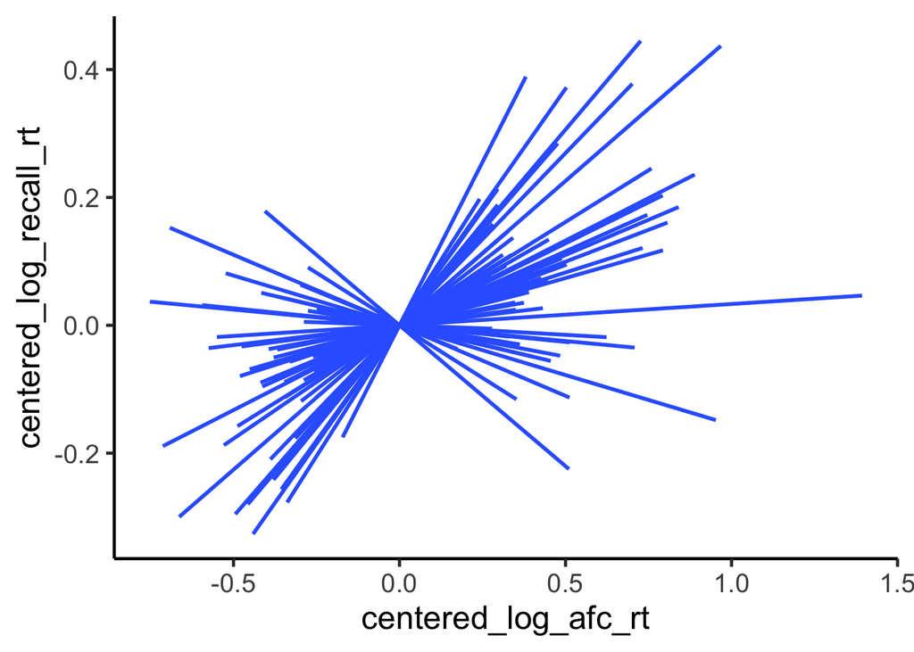

And here is the distribution of slopes (with 95% confidence intervals).

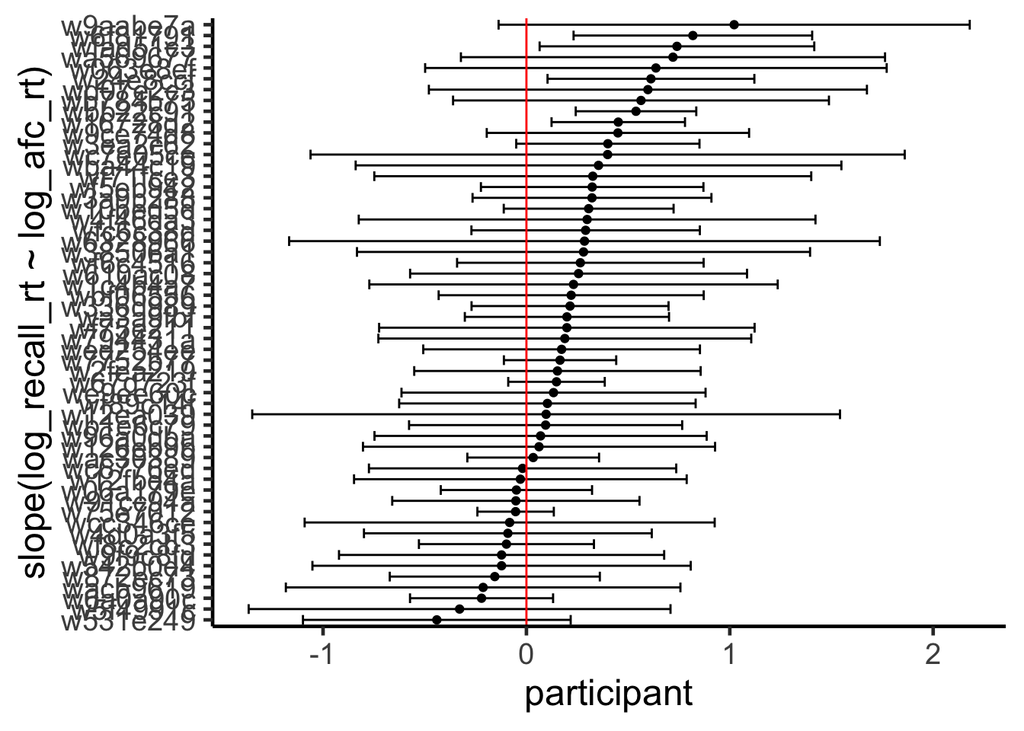

73% of participants have a positive slope. This is a good sign, but it’s still not great. The estimates are super noisy so it’s hard to know how much of this is real. Here’s a similar plot with the correlation.

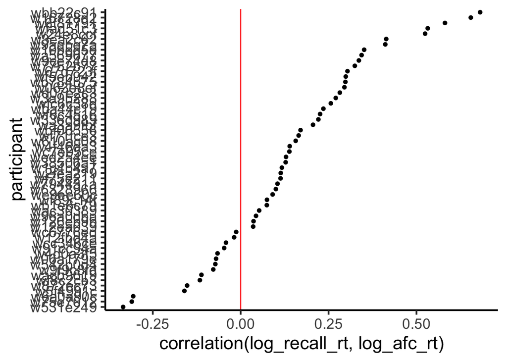

## AFC accuracy

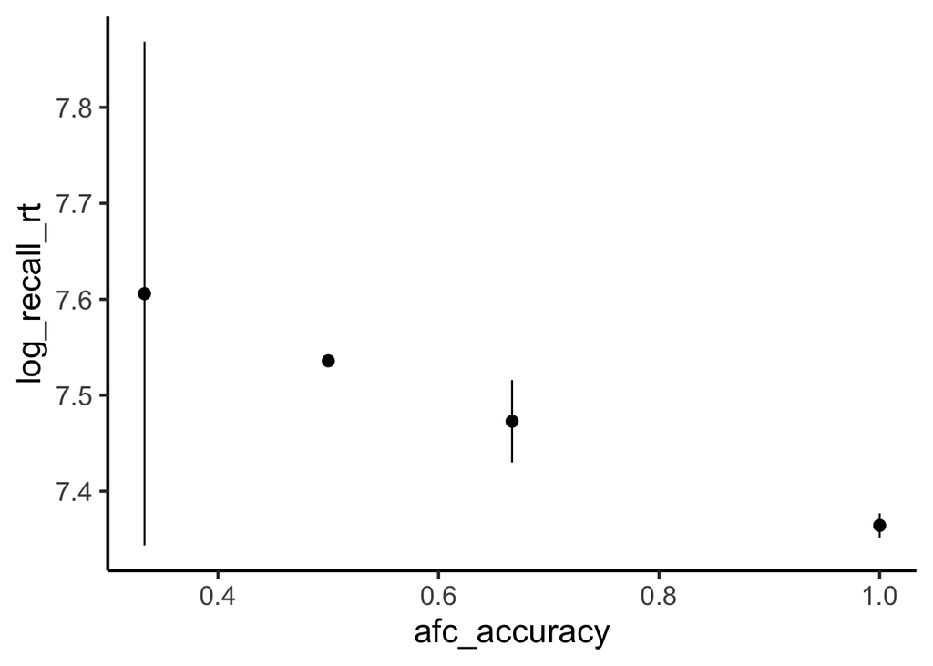

|  | Est. | S.E. | t val. | p |
| --- | --- | --- | --- | --- |
| (Intercept) | 7.697 | 0.106 | 72.825 | 0.000 |
| afc_accuracy | -0.333 | 0.109 | -3.056 | 0.002 |

Standard errors: OLS

This looks promising, but it turns out this one is driven entirely by individual differences (each line is a participant). Mixed effects regression shows no effect of 2AFC trials, especially when we account for RT on the correct 2AFC trials.

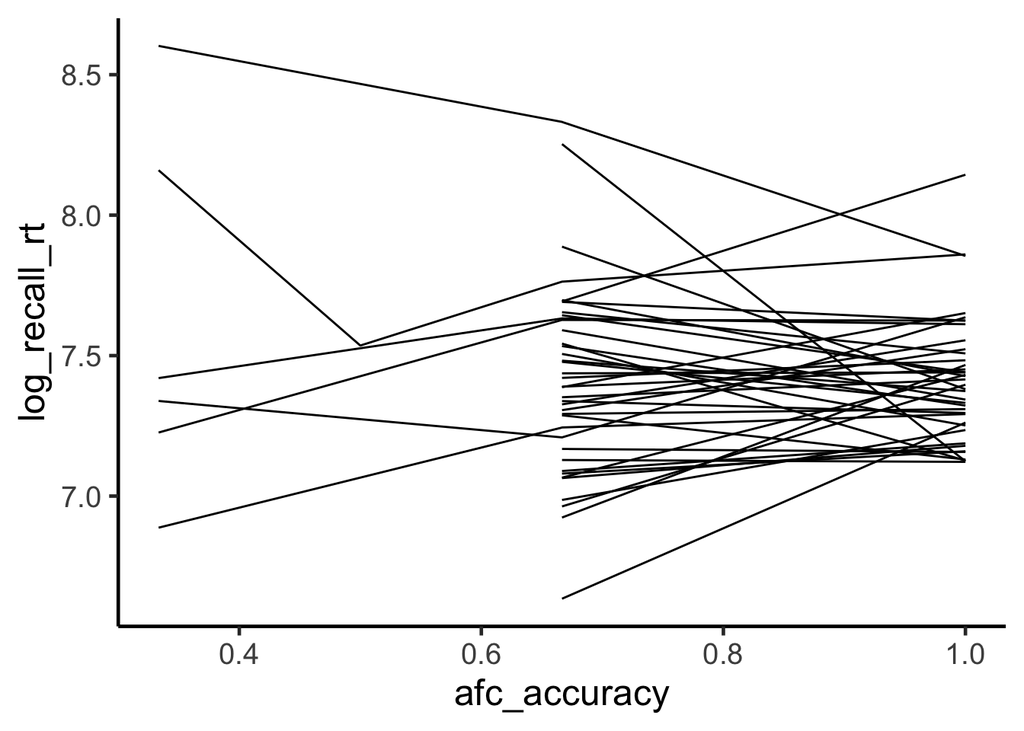

| Fixed Effects | Fixed Effects Est. | Fixed Effects S.E. | Fixed Effects t val. | Fixed Effects d.f. | Fixed Effects p |
| --- | --- | --- | --- | --- | --- |
| (Intercept) | 7.448 | 0.102 | 72.791 | 924.679 | 0.000 |
| afc_accuracy | -0.056 | 0.101 | -0.552 | 983.805 | 0.581 |

p values calculated using Satterthwaite d.f.

| Fixed Effects | Fixed Effects Est. | Fixed Effects S.E. | Fixed Effects t val. | Fixed Effects d.f. | Fixed Effects p |
| --- | --- | --- | --- | --- | --- |
| (Intercept) | 5.841 | 0.277 | 21.064 | 635.785 | 0.000 |
| afc_accuracy | -0.050 | 0.100 | -0.506 | 990.082 | 0.613 |
| log_afc_rt | 0.225 | 0.036 | 6.257 | 546.098 | 0.000 |

p values calculated using Satterthwaite d.f.

## Time course

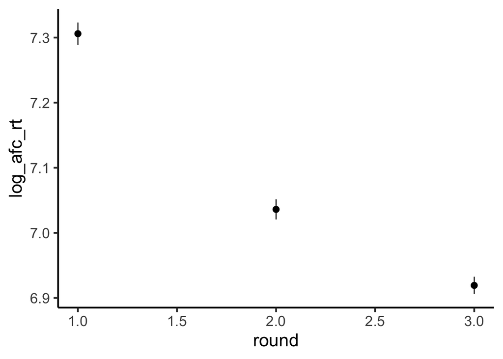

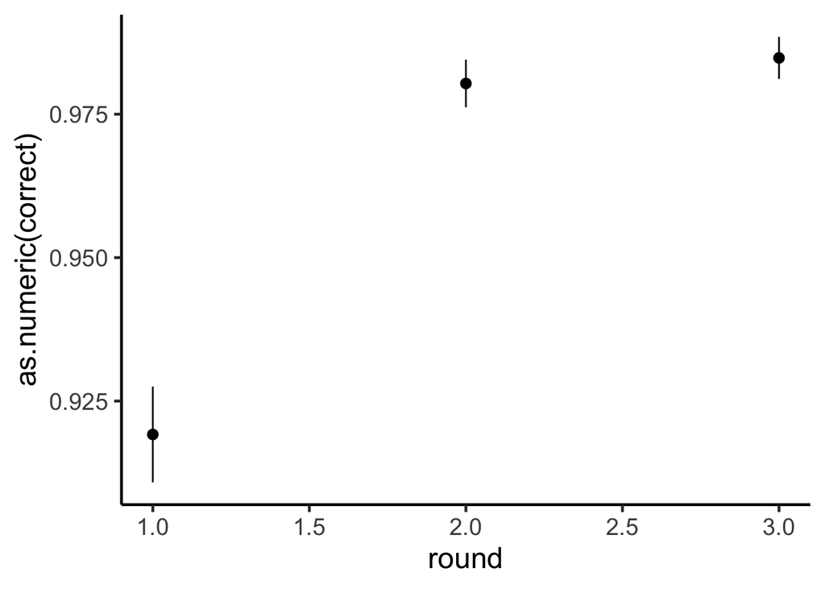

2AFC RT goes down, as we would expect.

| Fixed Effects | Fixed Effects Est. | Fixed Effects S.E. | Fixed Effects t val. | Fixed Effects d.f. | Fixed Effects p |
| --- | --- | --- | --- | --- | --- |
| (Intercept) | 5.410 | 0.316 | 17.127 | 420.386 | 0.000 |
| log_afc_rt1 | 0.087 | 0.028 | 3.145 | 897.553 | 0.002 |
| log_afc_rt2 | 0.089 | 0.036 | 2.497 | 873.248 | 0.013 |
| log_afc_rt3 | 0.104 | 0.038 | 2.746 | 933.154 | 0.006 |

p values calculated using Satterthwaite d.f.

The slope appears to be constant over rounds.

| lo | g_afc_rt1 lo | g_afc_rt2 lo | g_afc_rt3 lo | g_recall_rt |
| --- | --- | --- | --- | --- |
| log_afc_rt1 | 1.0000000 | 0.4038629 | 0.3723432 | 0.2376183 |
| log_afc_rt2 | 0.4038629 | 1.0000000 | 0.6515606 | 0.2791963 |
| log_afc_rt3 | 0.3723432 | 0.6515606 | 1.0000000 | 0.2733194 |
| log_recall_rt | 0.2376183 | 0.2791963 | 0.2733194 | 1.0000000 |

But the correlation is higher in rounds 2 and 3. (Look at the last column in the correlation matrix)

# Word type effects

## Accuracy

### All participants (before exclusion)

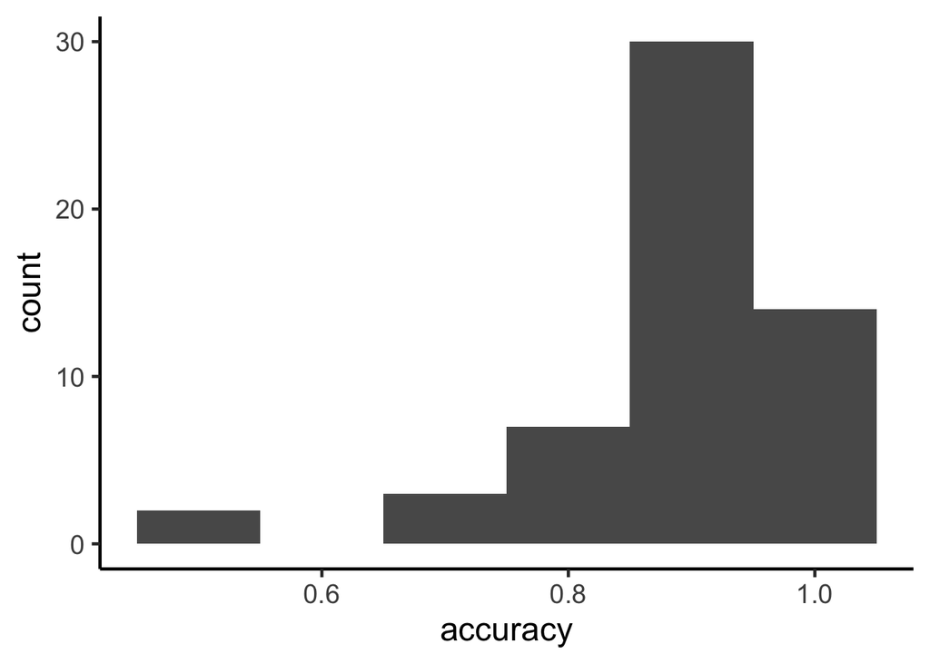

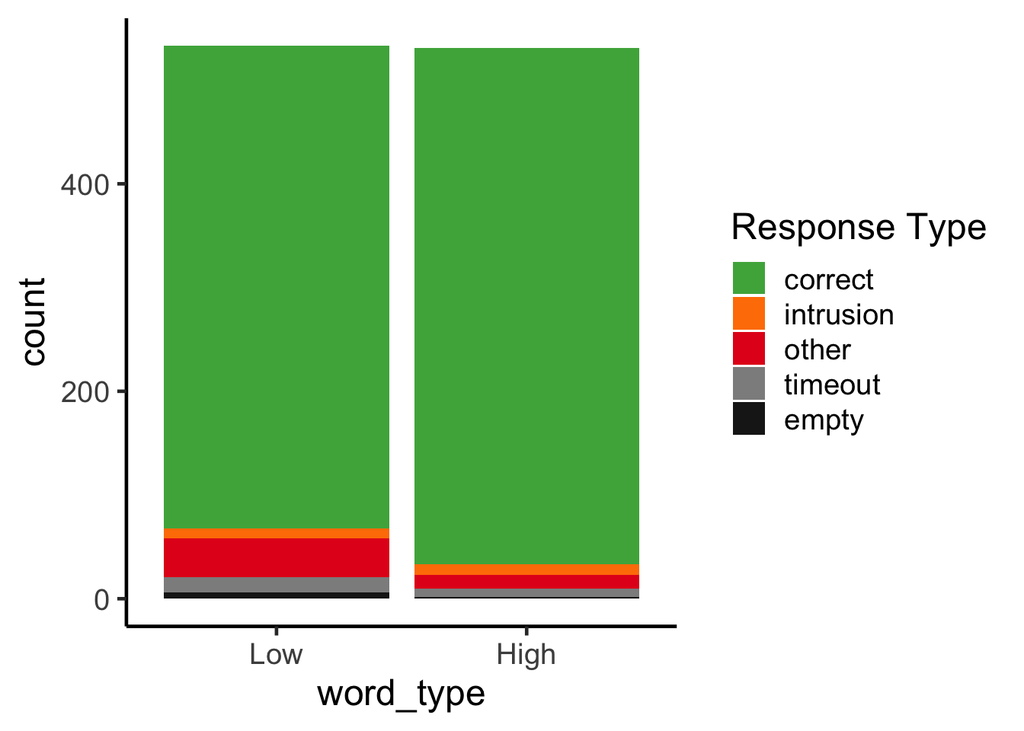

### Good participants (after exclusion)

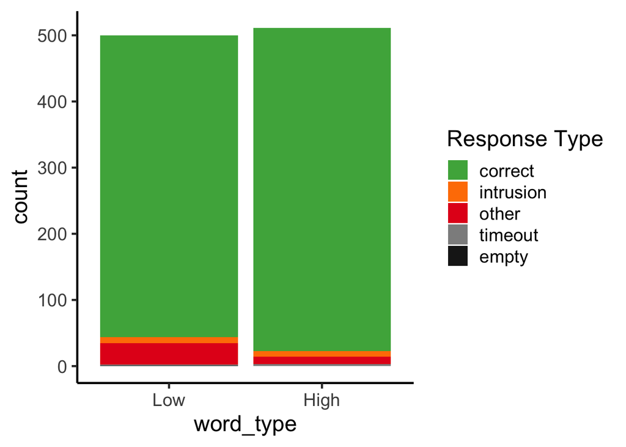

```r
glmer(correct ~ word_type + (1|wid), data=trials, family=binomial) %>% summ
```

| Fixed Effects | Fixed Effects Est. | Fixed Effects S.E. | Fixed Effects z val. | Fixed Effects p |
| --- | --- | --- | --- | --- |
| (Intercept) | 2.641 | 0.230 | 11.480 | 0.000 |
| word_typeHigh | 0.764 | 0.275 | 2.784 | 0.005 |

## Reaction time

### Aggregate

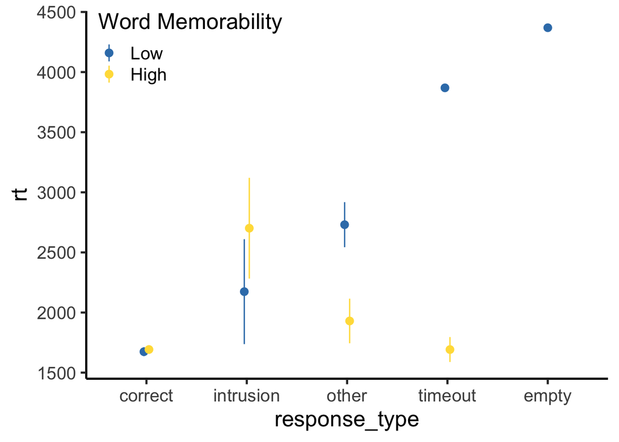

| response_type | word_type | rt |
| --- | --- | --- |
| correct | Low | 1674.164 |
| correct | High | 1692.467 |
| intrusion | Low | 2173.667 |
| intrusion | High | 2701.444 |
| other | Low | 2730.636 |
| other | High | 1929.818 |
| timeout | Low | 3869.000 |
| timeout | High | 1692.000 |
| empty | Low | 4369.000 |

### By participant

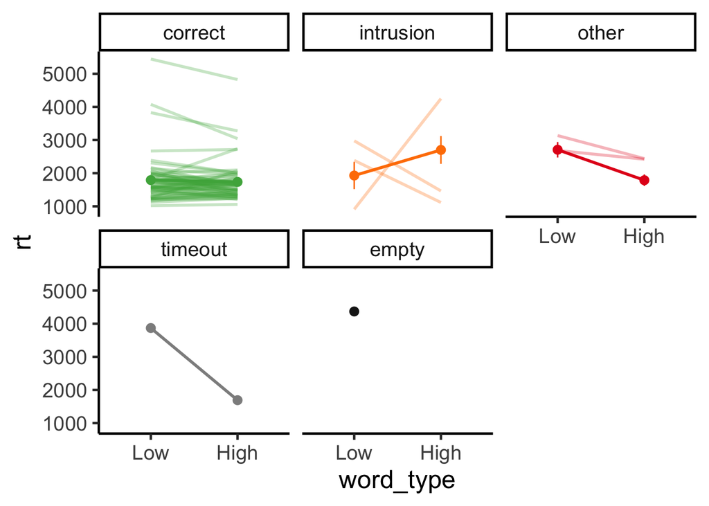

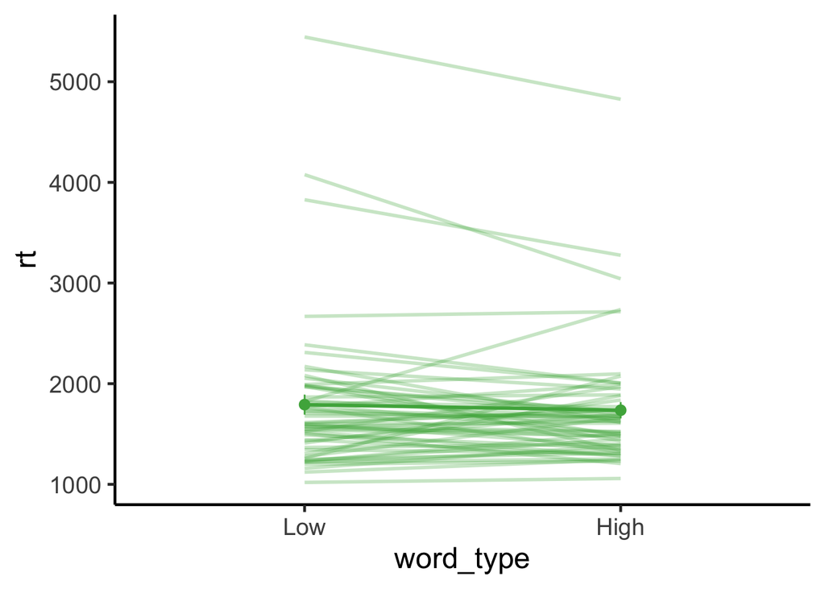

54% of participants respond faster on high memorability trials (including only correct response trials).

### Stats

```r
lmer(rt ~ word_type + (1|wid), data=trials) %>% summ
```

| Fixed Effects | Fixed Effects Est. | Fixed Effects S.E. | Fixed Effects t val. | Fixed Effects d.f. | Fixed Effects p |
| --- | --- | --- | --- | --- | --- |
| (Intercept) | 1821.721 | 79.698 | 22.858 | 57.285 | 0.000 |
| word_typeHigh | -68.450 | 44.304 | -1.545 | 948.059 | 0.123 |

p values calculated using Satterthwaite d.f.

```r
lmer(rt ~ word_type * response_type + (1|wid), data=trials) %>% summ
```

| Fixed Effects | Fixed Effects Est. | Fixed Effects S.E. | Fixed Effects t val. | Fixed Effects d.f. | Fixed Effects p |
| --- | --- | --- | --- | --- | --- |
| (Intercept) | 1753.206 | 77.653 | 22.578 | 58.804 | 0.000 |
| word_typeHigh | -19.914 | 44.398 | -0.449 | 942.125 | 0.654 |
| response_typeintrusion | 242.616 | 235.339 | 1.031 | 952.387 | 0.303 |
| response_typeother | 826.301 | 128.854 | 6.413 | 961.347 | 0.000 |
| response_typetimeout | 920.614 | 702.207 | 1.311 | 956.339 | 0.190 |
| response_typeempty | 2945.415 | 695.261 | 4.236 | 948.333 | 0.000 |
| word_typeHigh:response_typeintrusion | 847.250 | 329.578 | 2.571 | 948.359 | 0.010 |
| word_typeHigh:response_typeother | -772.189 | 246.936 | -3.127 | 950.830 | 0.002 |
| word_typeHigh:response_typetimeout | -1170.657 | 809.871 | -1.445 | 954.932 | 0.149 |

p values calculated using Satterthwaite d.f.

```r
lmer(rt ~ word_type + (1|wid), data=subset(trials, correct)) %>% summ
```

| Fixed Effects | Fixed Effects Est. | Fixed Effects S.E. | Fixed Effects t val. | Fixed Effects d.f. | Fixed Effects p |
| --- | --- | --- | --- | --- | --- |
| (Intercept) | 1759.616 | 82.035 | 21.449 | 55.809 | 0.000 |
| word_typeHigh | -20.775 | 42.281 | -0.491 | 881.621 | 0.623 |

p values calculated using Satterthwaite d.f.

```r
lmer(log_recall_rt ~ word_type + (1|wid), data=subset(trials, correct)) %>% summ
```

| Fixed Effects | Fixed Effects Est. | Fixed Effects S.E. | Fixed Effects t val. | Fixed Effects d.f. | Fixed Effects p |
| --- | --- | --- | --- | --- | --- |
| (Intercept) | 7.377 | 0.035 | 211.374 | 59.119 | 0.000 |
| word_typeHigh | -0.003 | 0.020 | -0.142 | 883.329 | 0.887 |

p values calculated using Satterthwaite d.f.

## Typing time

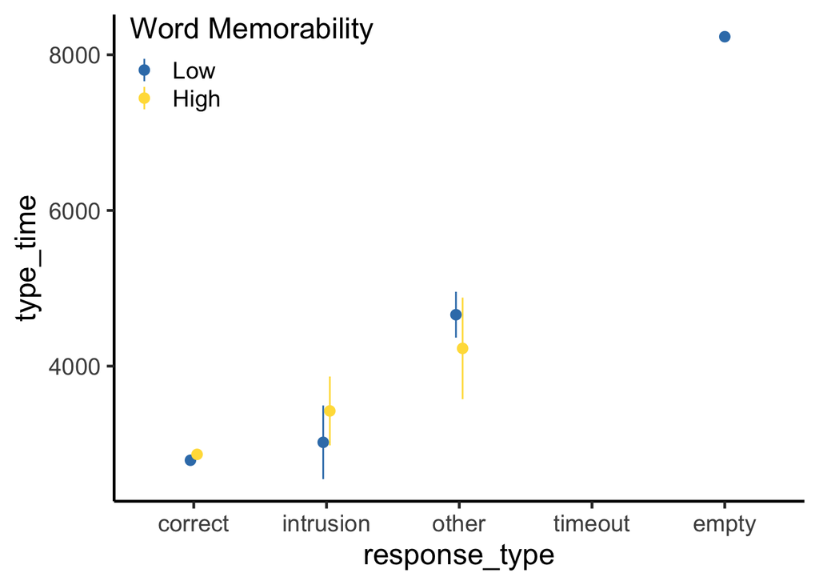

| response_type | word_type | type_time |
| --- | --- | --- |
| correct | Low | 2790.458 |
| correct | High | 2866.191 |
| intrusion | Low | 3021.130 |
| intrusion | High | 3424.214 |
| other | Low | 4660.534 |
| other | High | 4227.780 |
| timeout | Low | NA |
| timeout | High | NA |
| empty | Low | 8232.530 |

```r
lm(type_time ~ word_type, data=subset(trials, correct)) %>% summ
```

|  | Est. | S.E. | t val. | p |
| --- | --- | --- | --- | --- |
| (Intercept) | 2790.458 | 60.130 | 46.407 | 0.000 |
| word_typeHigh | 75.733 | 83.632 | 0.906 | 0.365 |

Standard errors: OLS

## Total response time

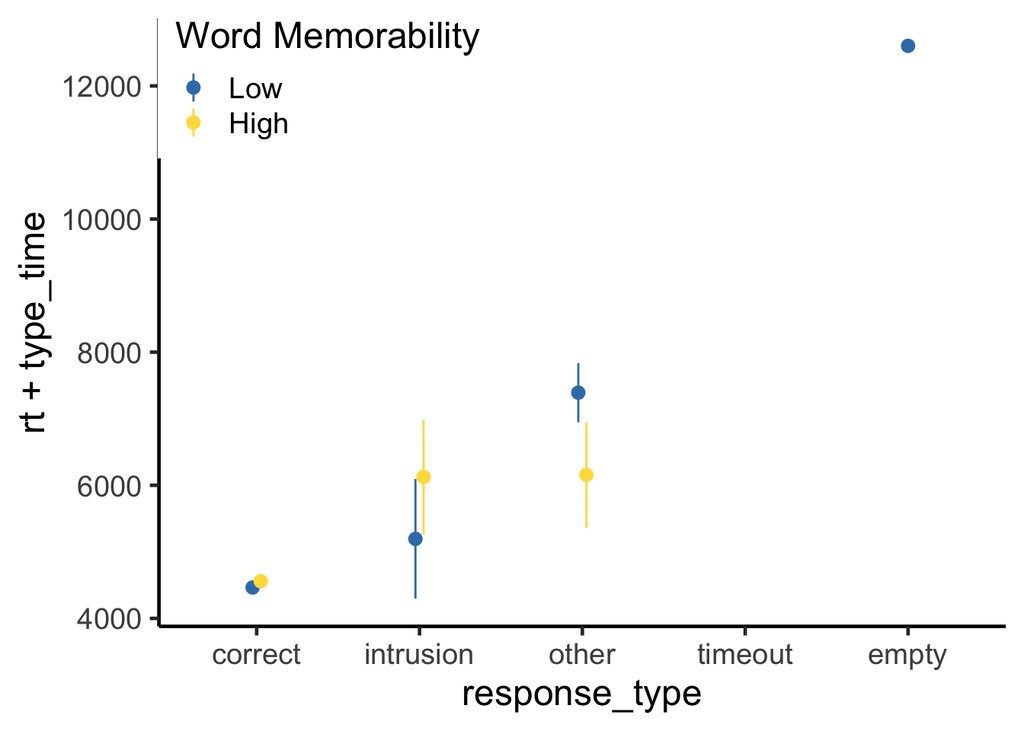

| response_type | word_type | total_time |
| --- | --- | --- |
| correct | Low | 4464.623 |
| correct | High | 4558.659 |
| intrusion | Low | 5194.797 |
| intrusion | High | 6125.658 |
| other | Low | 7391.170 |
| other | High | 6157.599 |
| timeout | Low | NA |
| timeout | High | NA |
| empty | Low | 12601.530 |

```r
lm(rt + type_time ~ word_type, data=subset(trials, correct)) %>% summ
```

|  | Est. | S.E. | t val. | p |
| --- | --- | --- | --- | --- |
| (Intercept) | 4464.623 | 90.656 | 49.248 | 0.000 |
| word_typeHigh | 94.036 | 126.087 | 0.746 | 0.456 |

Standard errors: OLS

## Check response coding

#### Responses classified as “other” (incorrect but not intrusion)

| word | response |
| --- | --- |
| dandelion | daffodil |
| tread | mark |
| barracuda | chapagie |
| grizzly | fefs |
| tread | e |
| seagull | fd |
| personnel | partner |
| goddess | superb |
| ozone | ozern |
| vagrant | vapous |
| traitor | trader |
| villain | villian |
| fellow | tranquil |
| stairs | staircases |
| house | home |
| frog | forg |
| rebel | rag |
| tread | trail |
| tread | trape |
| roost | roote |
| critic | civic] |
| captive | impact |
| rouge | rogue |
| villain | killer |
| patient | secrets |
| handkerchief | hankerchief |
| tart | idk |
| personnel | personelle |
| penguin | airport |
| application | applicant |
| suburb | suburban |
| personnel | personell |
| keeper | partner |
| patient | patience |
| rouge | terrain |
| roost | vacation |
| captive | captian |
| antelope | envelop |
| rouge | rogue |
| cookie | cookies |
| grizzly | quikky |
| editorial | literature |
| roost | rooster |
| daisy | target |

#### Non-exact matches classified as correct

| word | response |
| --- | --- |
| villain | villai |
| volunteer | volunteee |
| barracuda | baraccuda |
| chimney | chimeny |
| barracuda | baracuda |
| shoelace | shoelaces |
| seagull | seagul |
| horse | horses |
| suburb | suburbs |
| tulip | tulips |
| critic | critc |
| bug | bugs |
| barracuda | barricuda |
| scapegoat | scapegaot |
| refrigerator | refridgerator |
| handkerchief | handerchief |
| jeans | jean |
| flower | flowers |
| jeans | jean |
| banana | bananna |
| cauliflower | califlower |
| eagle | eagles |
| suburb | subrub |
| tomato | tomatoes |
| handkerchief | handkerchied |
| suburb | suburbs |